# 单变量绘图选择

# 双变量分析

### 探讨你在这部分探究中观察到的一些关系。这些感兴趣的特性与数据集内其他特性有什么区别？

- 酒精度与红葡萄酒品质呈正相关
- 挥发性酸与红葡萄酒品质呈负相关
- 柠檬酸与红葡萄酒品质呈正相关
- 硫酸盐含量与红葡萄酒品质呈正相关  
  这些感兴趣的特性与其他变量相比，都与主要特性——红葡萄酒的品质呈现相关性。

### 你是否观察到主要特性与其他特性之间的有趣关系？

- 密度与酒精度呈负相关
- 不挥发酸与柠檬酸、密度呈正相关
- 不挥发酸与pH呈负相关

### 你发现最强的关系是什么？

最强的关系是酒精度与红葡萄酒品质的正相关性，二者的相关系数达0.463。

# 多变量绘图选择

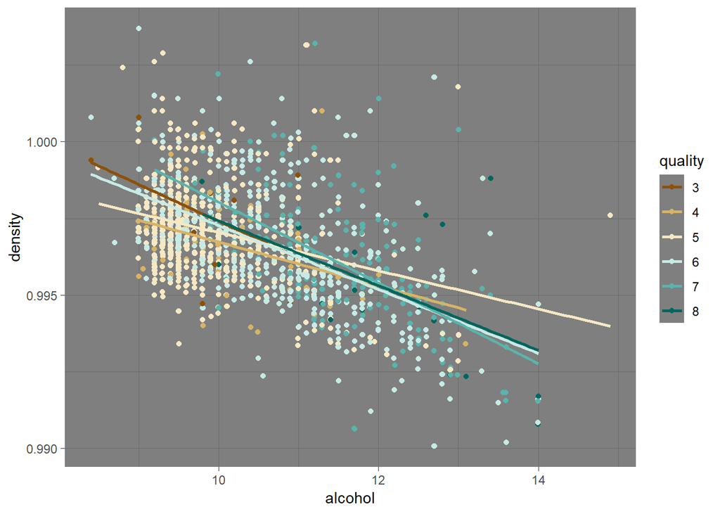

对于每一种评分，密度均与酒精度呈负相关。评分越高的酒的酒精度也越高。

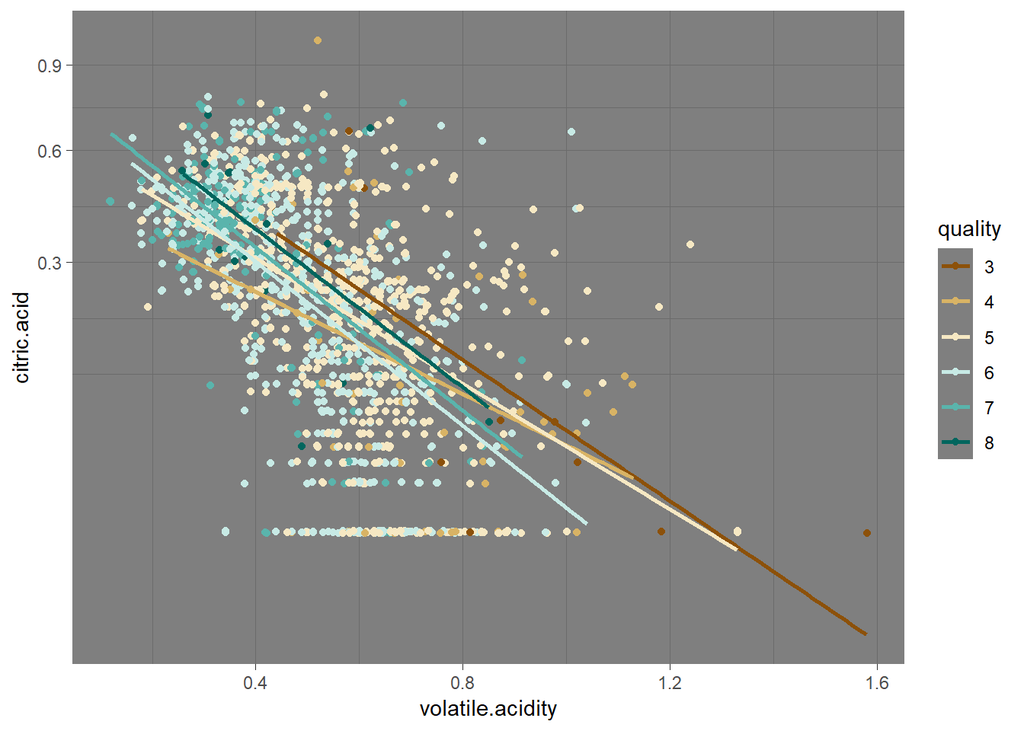

评分高的红葡萄酒含有更多的柠檬酸和更少的挥发性酸。因为柠檬酸带来的风味可以给红葡萄酒加分，挥发性酸中的乙酸会带来刺鼻的醋味给葡萄酒减分。

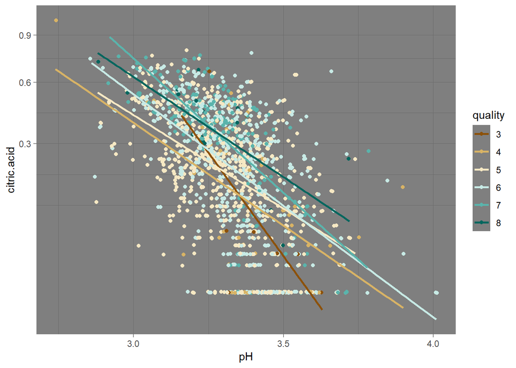

柠檬酸含量越高，pH值越低，这个符合常理。 不同品质的葡萄酒在pH3.0-3.6的范围均有分布。

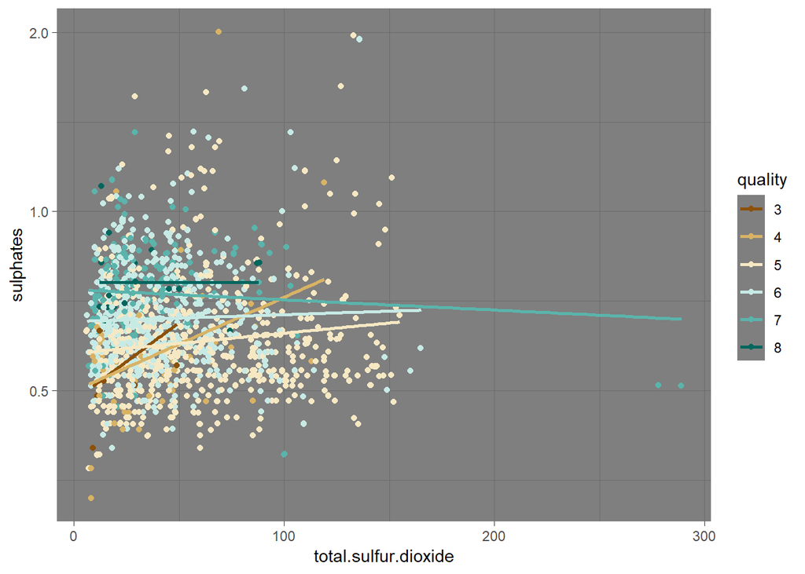

除评分最低的红葡萄酒外，品质越高的红葡萄酒含有较多的硫酸盐。 总二氧化硫含量与硫酸盐含量之间并没有预想的相关性。

# 多变量分析

### 探讨你在这部分探究中观察到的一些关系。通过观察感兴趣的特性，是否存在相互促进的特性？

酒精度、挥发性酸、柠檬酸、硫酸盐这4个变量与红葡萄酒品质的相关性均低于0.5，没有发现存在相互促进的特性。

### 这些特性之间是否存在有趣或惊人的联系呢？

硫酸盐和总二氧化硫无相关性，而我预期这两者呈正相关。 柠檬酸带来的风味可以给红葡萄酒加分，挥发性酸中的乙酸会带来刺鼻的醋味给葡萄酒减分。而柠檬酸和挥发性酸呈现负相关，是不是存在一种影响因素可以在降低挥发性酸的同时增加柠檬酸？

### 选项：你是否创建过数据集的任何模型？讨论你模型的优缺点。

# 定稿图与总结

### 绘图一

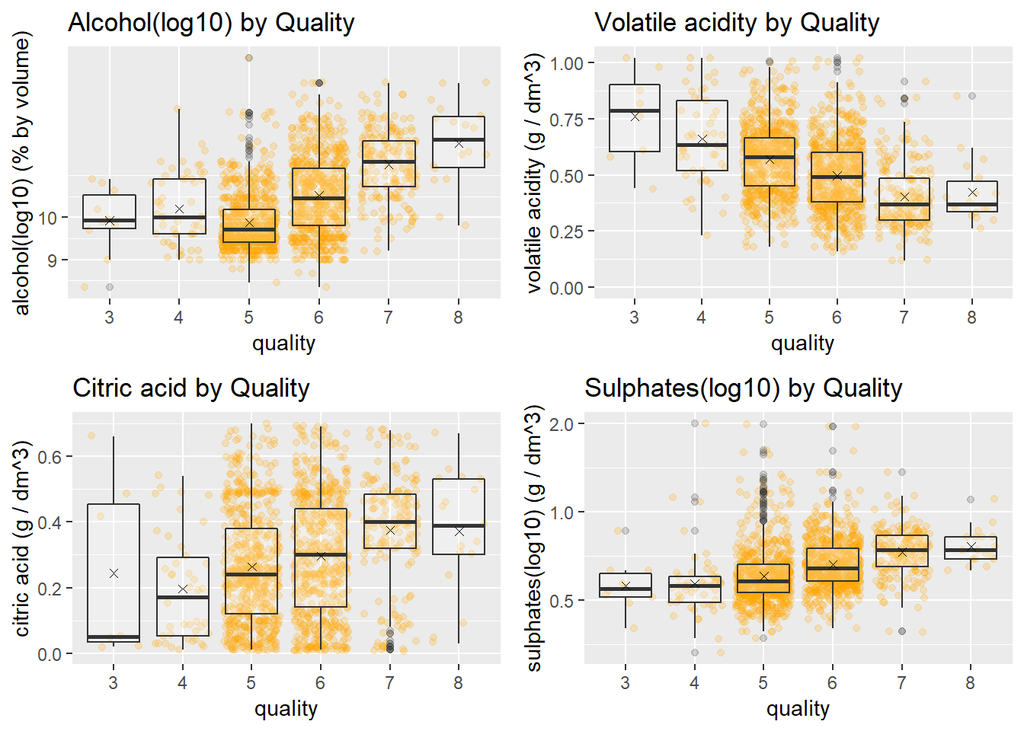

### 描述一

- 酒精度(log10)与红葡萄酒品质呈正相关
- 挥发性酸与红葡萄酒品质呈负相关
- 柠檬酸与红葡萄酒品质呈正相关
- 硫酸盐(log10)含量与红葡萄酒品质呈正相关

### 绘图二

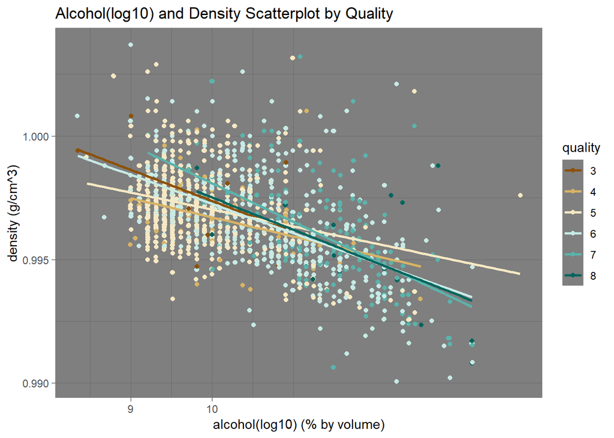

### 描述二

对于每一种评分，密度均与酒精度呈负相关。评分越高的酒的酒精度也越高。

### 绘图三

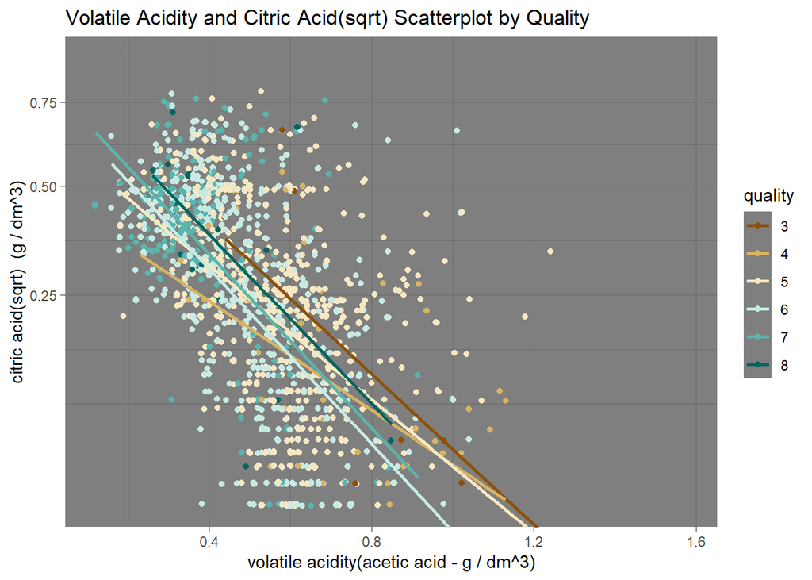

### 描述三

评分高的红葡萄酒含有更多的柠檬酸和更少的挥发性酸。因为柠檬酸带来的风味可以给红葡萄酒加分，挥发性酸中的乙酸会带来刺鼻的醋味给葡萄酒减分。而图中显示，柠檬酸和挥发性酸呈现负相关，是不是存在一种影响因素可以在降低挥发性酸的同时增加柠檬酸？

# 反思

分析过程中有3个方面让我觉得没有成就感：  
1.红葡萄酒品质数据集中缺乏像钻石数据集中的多个定序变量，因此不能以预想的方式从多个维度来进行分析，更多的只能进行单、双变量分析；  
2.没有发现对红葡萄酒品质相关性特别高的变量；  
3.一些预期出现的结果要么没有出现，要么与预期相反。

但经过这么多的分析，我意识到现实中的情况很复杂，很多因素相辅相成，且会含有我尚未观察到的相互作用机理，多种因素协同影响结果是非常正常的现象，这也凸现了数据分析的重要性。 此外，通过数据分析破除了我对总二氧化硫与硫酸盐的关系、柠檬酸与挥发性酸的关系的猜想，说明分析问题不能只靠直觉，而更应该靠可靠的数据分析。

考虑到这个数据集只有1599个观察值，且大部分都是中等品质的红葡萄酒，将来可以考虑加大数据量，特别是优质红酒的数据量。此外，葡萄酒的品质还与葡萄本身的种类和特点有关，将来可以考虑在数据集中加上此内容，以便更好的预测葡萄酒的品质。